# Testing a Viral Claim Against Florida’s Returns

What the Panhandle did: a claim about race and a Republican primary, tested four ways

Democracy’s Data

Last updated September 13, 2026 at 6:12p EDT

On 18 August 2026 Florida Republicans chose a nominee for governor in their primary, the party’s own election to pick its candidate. Byron Donalds won with 47.8% of a 11-candidate field, and 1,697,262 people voted. Donalds is Black. He is the first Black candidate Florida Republicans have nominated for governor; the Democrats nominated Andrew Gillum in 2018.[^1]

Then look at where his votes came from. In Collier County he took 65.8%. In Lafayette County he took 18.0%.

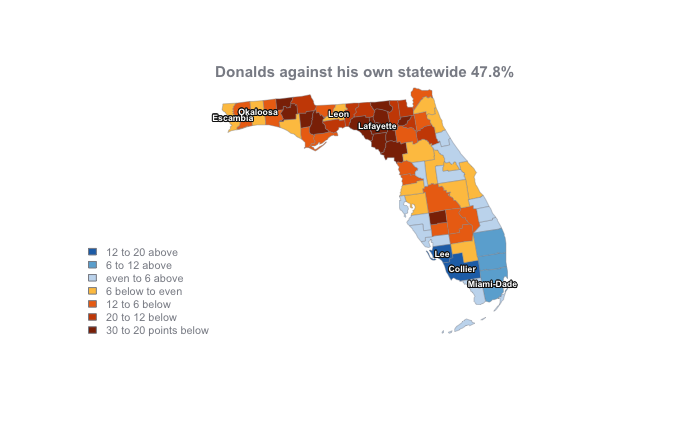

**Figure 1. Donalds against his own statewide share, county by county.** A map fits this question because the claim is about a place: each county is shaded by how far Donalds ran from his statewide 47.8%, on a diverging scale — one colour for above, another for below, pale at zero — because the sign is the subject. The deficit is not scattered. It is the north.

## The test

Every test runs on official returns published by the Florida Department of State’s Division of Elections: county-level results for every statewide contest in the 2026 primary. The 2018 and 2014 primaries sit beside them for comparison. The 2026 file is the one the state published after the counties finished canvassing — checking and totalling their returns before certifying them — not the Associated Press’s snapshot from election night. Alongside the returns sit the Division’s book-closing reports for the same primary: the registration rolls as they stood when registration closed, counted by county, party and race. That report is what lets the electorate be counted rather than guessed at.

Returns are the right instrument for the first three tests because they are complete and official: every accepted ballot is in them. And the same voters appear in four contests on one afternoon’s ballot, which is the natural experiment — a comparison the world set up without anyone designing it — the first test runs on. The returns-source chapter is this data’s biography: what a return is, who certifies it, and the one thing it can never contain, which is any record of an individual voter. That missing record is exactly where the fourth test will end.

## The data

The state’s files, one per contest, reduce to a handful of county tables. `county_results.csv` holds every candidate in every county: `county`, `candidate`, `votes`, `county_total` and `share`. `deviations.csv` holds each county’s `share` for each of the four statewide winners, the winner’s `statewide` share, and the `deviation` between them. That deviation is what makes a five-way race and a two-way race readable on one scale. `benchmark.csv` pairs each county’s `donalds_dev` with `desantis_dev` from 2018 and the `residual`, meaning what is left over after you subtract what 2018 predicts. `electorate.csv` carries each county’s registered Republicans by race from the book-closing report, and `regions.csv` and `williams.csv` aggregate the same numbers by region and candidate.

One constructed column is a decision worth knowing about. The regions are this brief’s own: sixteen Panhandle counties, thirteen in the Big Bend and north central belt, and the rest of Florida, assigned by geography before any result was read.

> **Before you read on, commit to a number.** The last contested Republican primary for Florida governor was 2018: Ron DeSantis against Adam Putnam. DeSantis is white, and was endorsed by Trump, as Donalds was. Write down how far below his statewide share you think DeSantis ran in these same Panhandle counties. Then write down whether you expect his county-by-county spread to be **wider or narrower** than Donalds’. Both numbers, before you read on.

## What it says about democracy

### Test one: the same voters, four times

The claim has an obvious rival. Maybe north Florida just votes against whoever is winning.

That is checkable, because four statewide Republican primaries ran on the same ballot that day. Governor, US Senator, Chief Financial Officer, Commissioner of Agriculture. **Same voters, same ballot, same afternoon.** If a region is simply hostile to frontrunners, all four winners take the hit.

| Region | Donalds (Gov) | Moody (Sen) | Ingoglia (CFO) | Simpson (Agr) |
| --- | --- | --- | --- | --- |
| Panhandle | −7.5 | +0.6 | −5.1 | +1.1 |
| Big Bend / north central | −18.7 | +1.4 | −6.5 | −1.7 |
| rest of Florida | +1.7 | −0.1 | +0.9 | −0.1 |

They do not all take the hit. In the Panhandle, Moody ran +0.6 and Simpson +1.1 against their own statewide shares, while Donalds ran −7.5. In the Big Bend the gap is wider still: Donalds −18.7.

So it is not turnout, and it is not a regional habit of rejecting frontrunners. **Something about the governor’s race specifically.** That is a real finding and it survives the rest of this brief.

### Test two: the same map, eight years earlier

DeSantis’ spread across the 67 counties was **51.9 points**. Donalds’ was 47.8. The white candidate’s map was the more uneven of the two.

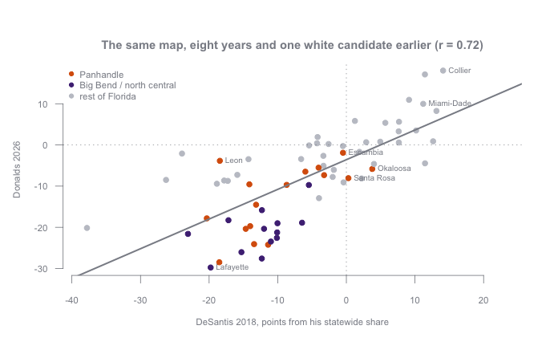

The two maps correlate at **0.72**, on a scale where 1 would mean the two maps line up perfectly and 0 would mean no relationship at all. Counties that ran below DeSantis in 2018 ran below Donalds in 2026, in nearly the same order, at nearly the same size. In the Panhandle, DeSantis ran −5.2 against his statewide share and Donalds ran −7.5 — a difference of 2.2 points. Most of what the first map shows you was already there before Donalds ran.

Not all of it, and the exceptions are where the claim has its best evidence. Okaloosa and Santa Rosa are large, white, heavily Republican Panhandle counties holding 48,758 primary votes for governor between them, and both sat *above* DeSantis’ statewide share in 2018. In 2026 both sat well below Donalds’.

| County | GOP votes | Donalds | Vs his statewide | DeSantis 2018 | Left unexplained |
| --- | --- | --- | --- | --- | --- |
| Lafayette | 1,659 | 18.0% | −29.8 | −19.8 | −11.9 |
| Liberty | 1,575 | 19.3% | −28.5 | −18.5 | −11.6 |
| Dixie | 3,410 | 20.2% | −27.6 | −12.3 | −15.1 |
| Gilchrist | 3,967 | 21.8% | −26.0 | −15.3 | −11.4 |
| Calhoun | 2,339 | 23.6% | −24.2 | −11.4 | −12.4 |
| Holmes | 3,345 | 23.7% | −24.1 | −13.4 | −10.8 |
| Hamilton | 1,628 | 24.3% | −23.5 | −11.0 | −12.0 |
| Suwannee | 6,441 | 25.2% | −22.6 | −10.1 | −11.7 |
| Union | 1,982 | 26.2% | −21.6 | −23.1 | −1.4 |
| Taylor | 2,837 | 26.5% | −21.2 | −10.1 | −10.4 |

Read the last column carefully. It is what 2018 does not account for. Some of it is large.

### Test three: where the missing votes went

A deficit is also a surplus somewhere. Donalds’ missing points in north Florida went to somebody, and who received them narrows the question a great deal.

| Candidate | Statewide | Panhandle | Big Bend / north central | Rest of Florida |
| --- | --- | --- | --- | --- |
| Donalds | 47.8 | 40.3 | 29.1 | 49.5 |
| Collins | 25.2 | 29.0 | 32.1 | 24.4 |
| Fishback | 10.5 | 11.0 | 12.1 | 10.3 |
| Renner | 8.5 | 11.4 | 10.4 | 8.1 |
| Williams | 4.1 | 4.2 | 13.7 | 3.6 |

In the Panhandle they went mostly to Collins and Renner, and Renner is a former speaker of the Florida House from Palm Coast — a north Florida figure.[^2] In the Big Bend something else happened. **Bobby Williams took 4.1% of the state and 13.7% of the Big Bend.** A candidate with 4 per cent of the state absorbed roughly half the region’s shortfall. So where is his vote?

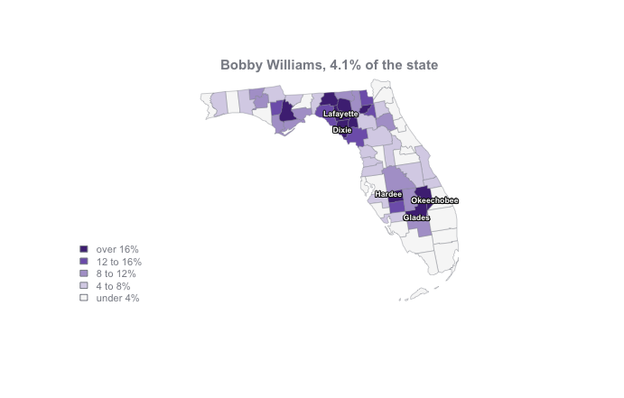

Not in one region. His best county is Lafayette at 28.5%. The rest of his top ten includes Glades, Hardee and Okeechobee, which are cattle and citrus counties in the middle of the peninsula, three hundred miles from the Panhandle. Hardee is 42.9% Hispanic and gave Donalds 27.6%.

That footprint is agricultural. It is not northern, and it is not obviously racial. Whatever Williams was to those voters, he was the same thing to them in Okeechobee as in Lafayette.

### Test four: the county’s people are not the primary’s voters

The natural next move is to put race in the picture directly: take each county’s share of Black residents and see whether Donalds ran worse where it is higher.

Do not make that move. It is the ecological fallacy: reasoning from a group’s share of an area to how members of that group behaved. Here it fails in an unusually clean way, because Florida registers voters by party and reports them by race, so the electorate can be counted. **In the Panhandle, 7,544 of 525,542 registered Republicans are Black.** That is 1.4%. A county’s population is not its primary electorate: Gadsden County is more than half Black and cast 2,258 Republican ballots for governor.

| County characteristic | With his geography | With what 2018 leaves | Range across the 67 counties |
| --- | --- | --- | --- |
| Black % of registered Republicans | 0.23 | 0.26 | 4.3 points |
| Hispanic % of registered Republicans | 0.44 | 0.44 | 75.1 points |
| white % of registered Republicans | -0.50 | -0.47 | 79.7 points |
| Black % of county population | -0.16 | 0.01 | 49.5 points |

The county-population measure gives 0.01 against what 2018 leaves unexplained — nothing at all. Switching to the registration measure moves it to 0.26, which is weak and positive, meaning Donalds did slightly *better* where more Black Republicans live. Neither number is worth much, and the last column says why.

### What the standard method would add, and where it stops

There is a standard method for questions like this. Racially polarized voting analysis, used in Voting Rights Act litigation to show that voters of different races choose different candidates,[^3] estimates how each racial group voted from precinct returns and precinct composition. The levels-of-aggregation chapter grades that family of methods against a counted truth and watches it return an impossible number without complaint.

The pieces are more available than they look. 17 of the 29 north Florida counties published precinct results, and they are in this brief’s `raw/`. Florida’s voter file is public by law and carries race, party and precinct on every record, so precinct composition can be counted rather than modelled. What stands between you and the file is a written request rather than a download link — a gap the voter-file-access brief measures across all fifty states. So the honest position is not that the method is impossible here. It is that **it would tell you something you already know, and still not tell you the thing in dispute.**

| Region | White share of registered Republicans | Donalds | So white Republicans gave him | Window |
| --- | --- | --- | --- | --- |
| Panhandle | 91.3% | 40.3% | 34.6% to 44.2% | 9.5 points |
| Big Bend / north central | 91.5% | 29.1% | 22.5% to 31.8% | 9.3 points |
| rest of Florida | 76.3% | 49.5% | 33.8% to 64.9% | 31.1 points |
| STATEWIDE | 78.1% | 47.8% | 33.2% to 61.2% | 28.0 points |

Here is why. Where an electorate is nearly all white, the overall result very nearly *is* the white result, and no model is required to see it. 91.3% of the Panhandle’s registered Republicans are white, and Donalds took 40.3% there. Now do the arithmetic both ways. Suppose every non-white Republican voted for him: the non-white 8.7% of the electorate supplies 8.7 of his 40.3 points, white voters must supply the remaining 31.6, and that is 34.6% of the white vote. Suppose instead that none did: white voters supplied all 40.3 points, which is 44.2% of the white vote. So white Republicans gave him between **34.6% and 44.2%**. That is a 9.5-point window, it needs no assumptions at all, and it is the method of bounds Duncan and Davis published in 1953.[^4]

Notice which way the homogeneity cuts. Statewide, the same calculation gives a 28.0-point window, which is useless, because Florida’s Republican electorate is 21.9% non-white and there is real room for the groups to differ. **The uniformity that makes an estimate for Black Republicans hopeless is exactly what makes the white estimate nearly exact.** In Holmes County, 36 of the registered Republicans are Black and 97.2% are white. Whatever happened in Holmes, white Republicans did it.

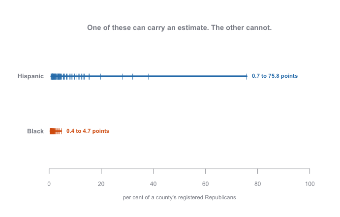

**The wall is not measurement. It is attribution.** We can say with confidence that somewhere around four in ten white Panhandle Republicans voted for Donalds. No voter file says why the other six did not. Was it because he is Black, because he is from Naples, because the governor’s office backed Jay Collins, or because Bobby Williams was the one who came to the county fair? The file has no column for it.

## What this brief cannot tell you

**It cannot tell you the claim is false.** Nothing here rules out that some Panhandle Republicans declined to vote for a Black candidate. Okaloosa and Santa Rosa moved several points against the frontrunner relative to 2018, and no benign explanation offered here fully accounts for them.

**It cannot tell you the claim is true.** The region’s deficit is mostly older than the candidate, and a white candidate drew it in 2018. An agricultural candidate whose base runs to the bottom of the peninsula absorbs much of the rest. What is left does not track the racial composition of the electorate in either direction with any strength.

**It cannot separate four things that move together.** Donalds is Black, is from Naples, was Trump’s endorsee against the sitting governor’s ally, and is a metropolitan south Florida congressman. North Florida is distant from Naples, rural, agricultural, and was DeSantis’ base. Every one of those alignments predicts the same map, and 67 counties cannot pull them apart.

**And it cannot be fixed with better data of this kind.** More precincts, finer geography and newer census figures all leave the attribution wall exactly where it is. What would settle the claim is a different instrument: a survey of Republican primary voters with a candidate-choice question and a race question, or an experiment varying a candidate’s race. The returns record 1,697,262 decisions and not one reason. Whichever way you already lean on this claim, the map at the top of this brief is consistent with your view, which is the surest sign that it is not evidence.

## What you should have learned

- A viral claim can be turned into a question and tested: the returns confirm a real, governor’s-race-specific deficit — Donalds ran −7.5 in the Panhandle while the same voters gave Moody +0.6 on the same ballot.
- Most of the pattern predates the candidate: the 2026 map correlates at 0.72 with DeSantis’ 2018 map, and the white candidate’s spread, 51.9 points, was wider than Donalds’ 47.8.
- Reasoning from a county’s population to its voters is the ecological fallacy; counting the actual electorate changes the answer, because only 1.4% of the Panhandle’s registered Republicans are Black.
- Where an electorate is 91.3% white, arithmetic alone bounds the white vote inside a 9.5-point window — and no data of this kind can say *why* anyone voted.

## Extensions

- `benchmark.csv` has each county’s `residual` — what 2018 does not explain. Sort it and look at the top and bottom fifteen. Do they share anything the brief did not name, and would you have called that a racial pattern if you saw it first?
- `williams.csv` gives Bobby Williams’ `share` in every county. Pick his fifteen best and find them in `electorate.csv`. Are they alike in the composition of their Republican electorate, or only in being rural?
- `deviations.csv` has all four statewide winners in all 67 counties. Ingoglia is the one whose `deviation` pattern most resembles Donalds’. Work out where the two agree and where they part. What does the agreement rule out?
- `electorate.csv` has registered Republicans by race beside `regions.csv`. Work out how many Black Republicans live in the counties where Donalds ran furthest behind. Could their votes have moved his share in those counties at all?
- `county_results.csv` has every candidate in every county. Collins and Renner both gained where Donalds lost. Which of the two better predicts the counties Donalds lost ground in, and what would each answer imply?
- **Stretch.** The precinct returns for 17 north Florida counties are in this brief’s `raw/`. Compute the method of bounds for one county’s precincts and see how much narrower the windows get.
- **Stretch.** Write the records request for Florida’s voter file and count one county’s Republican electorate by precinct and race. Does the answer land inside the window the brief already knew?

## Sources

**Data**

- Florida Department of State, Division of Elections, *2026 Primary Election, 18 August 2026*, results by county for every office. https://flelectionfiles.floridados.gov/enightfilespublic/20260818_ElecResultsFL.txt The Division’s Florida Election Watch site links this and three other formats. https://floridaelectionwatch.gov/Downloads
- Florida Department of State, Division of Elections, *2018* and *2014 Primary Election* results, from the results archive’s extract utility. https://results.elections.myflorida.com/
- The Associated Press count of the same election, as carried by NPR on the night, is in this brief’s `raw/` and is not what any figure above is built from. https://apps.npr.org/primary-election-results-2026/states/FL.html It is a snapshot frozen at 99% of precincts reporting; the state’s file is the one used because it was published after the counties finished canvassing, and the wire service’s was not.
- Florida Department of State, Division of Elections, *Book Closing Reports*, 2026 Primary — active registered voters by county, party and race, and by precinct and party. https://dos.fl.gov/elections/data-statistics/voter-registration-statistics/bookclosing/
- Precinct returns for 17 north Florida counties, from each county supervisor of elections through the state’s election-night platform. https://enr.electionsfl.org/ Each county’s own address is in `data/raw/enr_county_manifest.tsv`, because nothing indexes them.
- County outlines and the 2024 presidential margin come from the mapping brief’s tables; county population by race from the surnames chapter.

**The data itself**

Every figure above is drawn from these tables. They are plain CSV, they open in a spreadsheet, and they are yours to take further.

`benchmark.csv`, `bounds.csv`, `candidate_by_region.csv`, `correlates.csv`, `county_map.csv`, `county_map_labels.csv`, `county_results.csv`, `deviations.csv`, `electorate.csv`, `regions.csv`, `williams.csv`

One more file is not data about the subject – it is how this chapter checked its own numbers: `facts.csv`, the individual numbers the text above quotes.

**Academic literature**

- Highton, B. (2004). “White Voters and African American Candidates for Congress.” *Political Behavior* 26(1): 1–25. https://link.springer.com/article/10.1023/B:POBE.0000022341.98720.7e
- Hopkins, D. J. (2009). “No More Wilder Effect, Never a Whitman Effect: When and Why Polls Mislead about Black and Female Candidates.” *Journal of Politics* 71(3): 769–781. https://www.jstor.org/stable/10.1017/s0022381609090519
- Amos, B., McDonald, M. P. and Watkins, R. (2017). “When Boundaries Collide: Constructing a National Database of Demographic and Voting Statistics.” *Public Opinion Quarterly* 81(S1): 385–400. doi:10.1093/poq/nfx001.
- Duncan, O. D. and Davis, B. (1953). “An Alternative to Ecological Correlation.” *American Sociological Review* 18(6): 665–666. https://www.jstor.org/stable/2088122
- King, G. (1997). *A Solution to the Ecological Inference Problem.* Princeton University Press. https://press.princeton.edu/books/paperback/9780691012407/a-solution-to-the-ecological-inference-problem
- *Thornburg v. Gingles*, 478 U.S. 30 (1986). https://www.law.cornell.edu/supremecourt/text/478/30

Why this data cannot be fetched again

```
Most of this chapter's data can be downloaded again today. One tier
cannot, and the reason it cannot is one of the chapter's own points.

WHAT STILL DOWNLOADS. Everything the argument actually rests on.
Florida's Department of State publishes county-by-county results for
the 18 August 2026 primary, every office, as an open download:
https://flelectionfiles.floridados.gov/enightfilespublic/20260818_ElecResultsFL.txt
The 2018 and 2014 primaries come from the same Division's results
archive at https://results.elections.myflorida.com/ -- pick the
election, then the download utility. And the book-closing reports at
https://dos.fl.gov/elections/data-statistics/voter-registration-statistics/bookclosing/
give active registered voters by county, party and race for this
election, which is the file that closes the argument.

WHY THE PRECINCT TIER DOES NOT. Florida compiles a statewide precinct
file, and it was not out when this was written: the 2024 primary's
appeared ten months after that election. So precinct results existed
only where each of 67 county supervisors put them, at addresses
holding a per-county election id and a per-file UUID that nothing
indexes. Those ids were found by scanning and are recorded in
raw/enr_county_manifest.tsv. Counties retire the pages. Note that the
chapter uses those returns to show what the standard method would and
would not add, so a rebuild that skips them loses an example rather
than a result. Florida's voter file, which carries race, party and
precinct on every record, is public and free but needs a written
request to the Division of Elections; the chapter explains why having
it would not change the answer.

WHAT YOU CAN STILL CHECK. These numbers say whether you are holding
the same objects:
- Byron Donalds won the Republican primary for governor with 47.79%
  of an 11-candidate field and 1697262 votes, ranging from 18.02% in
  Lafayette County to 65.84% in Collier
- the other three statewide Republican winners on that ballot spread
  much less across the counties -- 20.6, 25.6 and 16.0 points against
  the governor's 47.8
- Ron DeSantis, white, won the 2018 primary for the same office with
  56.49% and a WIDER county spread, 51.9 points, and the two maps
  correlate at 0.72
- in the Panhandle, 7544 of 525542 registered Republicans are Black,
  which is 1.4%
- across all 67 counties the Black share of registered Republicans
  runs from 0.4% to 4.7%, while the Hispanic share runs from 0.7% to
  75.8%
```

[^1]: On the primary result, Ballotpedia, 20 August 2026: https://news.ballotpedia.org/2026/08/20/byron-donalds-defeated-10-other-candidates-in-the-republican-primary-for-governor-of-florida-on-aug-18/. On Donalds and Gillum as the two nominees, TheGrio, 18 August 2026: https://thegrio.com/2026/08/18/byron-donalds-wins-florida-gop-primary-first-black-governor/.
[^2]: Paul Renner led the House from 2022 to 2024 and entered the race from Palm Coast: https://baynews9.com/fl/tampa/news/2025/09/03/paul-renner--former-florida-house-speaker--announces-governor-bid.
[^3]: The evidence the courts require was set out in *Thornburg v. Gingles*, 478 U.S. 30 (1986): https://www.law.cornell.edu/supremecourt/text/478/30.
[^4]: Otis Dudley Duncan and Beverly Davis, “An Alternative to Ecological Correlation,” *American Sociological Review* 18, no. 6 (1953): 665–666, https://www.jstor.org/stable/2088122.